# Project Bayes

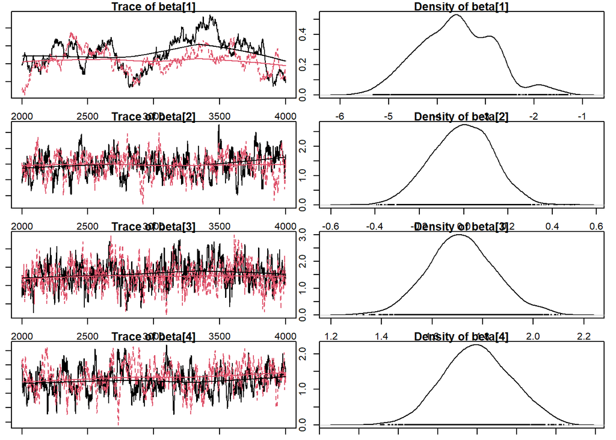

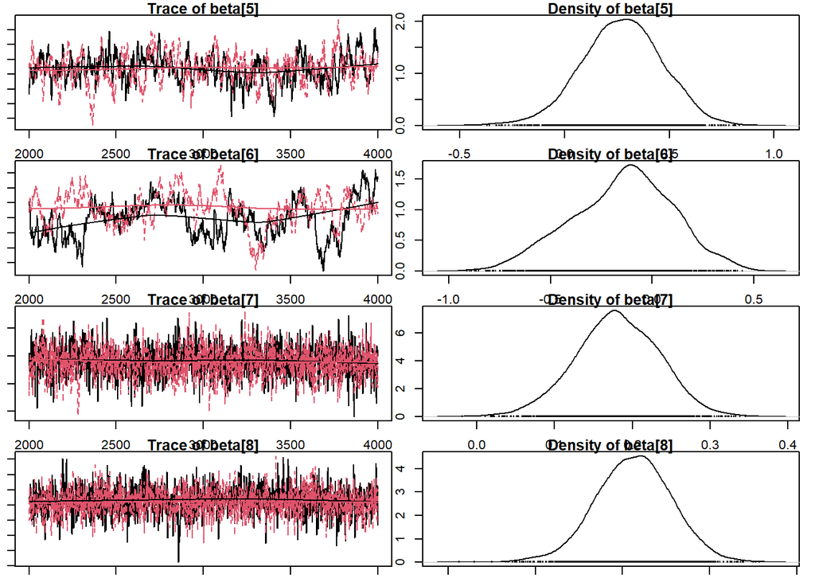

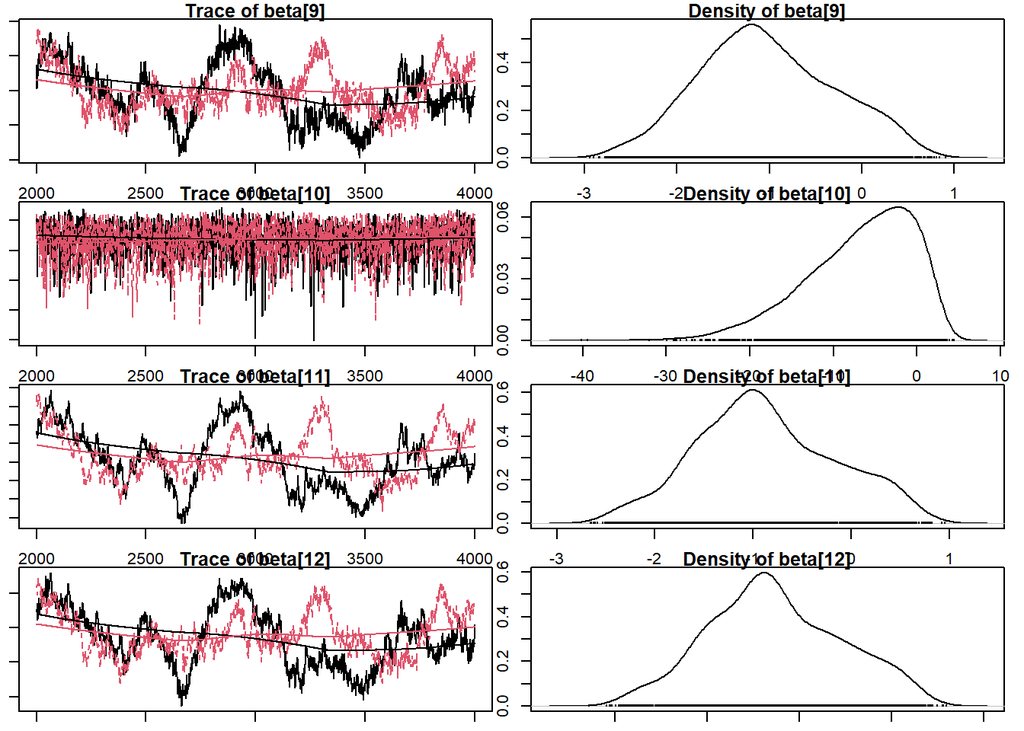

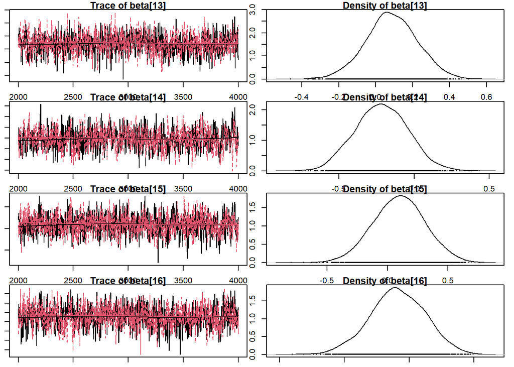

```r
par(mar=c(1,1,1,1))
plot(beta_samples2)
```

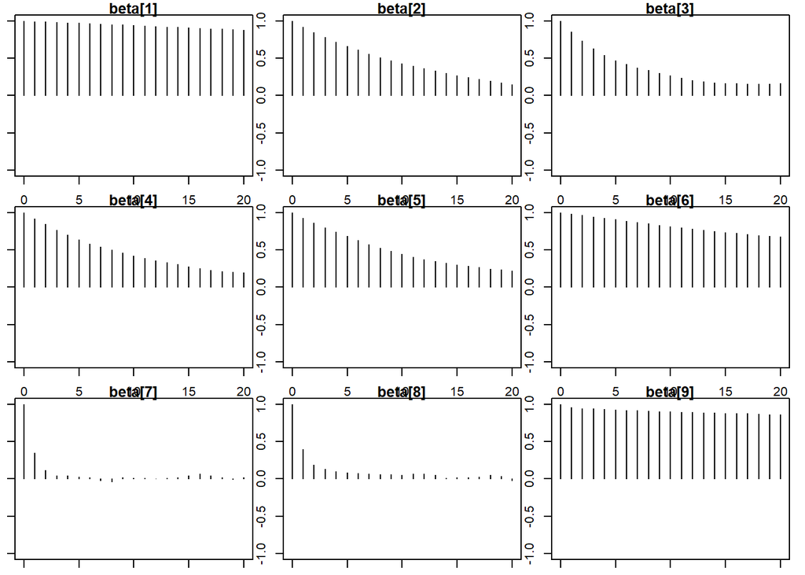

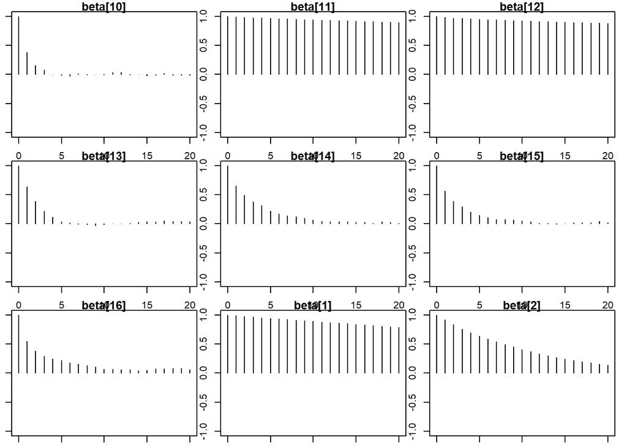

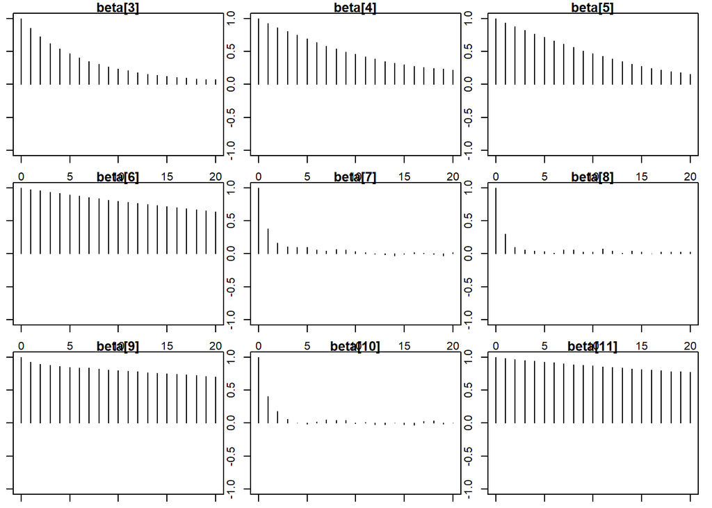

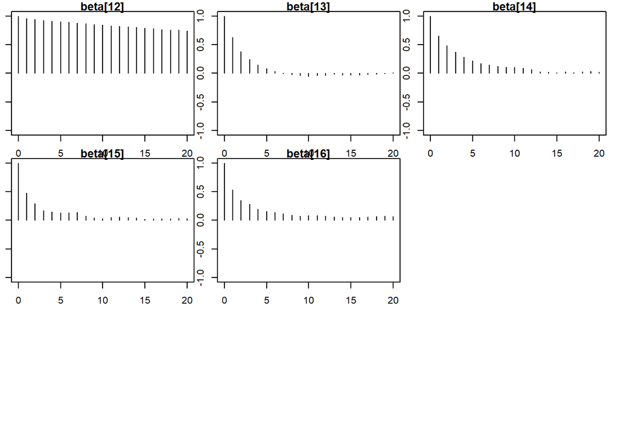

```r
par(mar=c(1,1,1,1))
autocorr.plot(beta_samples2)
```

```r
autocorr(beta_samples2[[2]],lag=5)
```

```
## , , beta[1]
##
##         beta[1]     beta[2]  beta[3]    beta[4]    beta[5]    beta[6]
## Lag 5 0.9427215 0.007140326 0.213951 -0.3464594 -0.2711308 -0.3972654
##          beta[7]    beta[8]    beta[9]    beta[10]   beta[11]   beta[12]
## Lag 5 0.04001066 0.07053381 -0.4709484 -0.04070794 -0.4848559 -0.4822787
##        beta[13]    beta[14]    beta[15]   beta[16]
## Lag 5 -0.138142 -0.07182515 0.003970282 -0.1348474
##
## , , beta[2]
##
##           beta[1]   beta[2]   beta[3]   beta[4]    beta[5]    beta[6]
## Lag 5 -0.09581107 0.6372119 0.2646374 0.1645098 0.03846153 0.04154772
##          beta[7]    beta[8]    beta[9]   beta[10]   beta[11]   beta[12]
## Lag 5 -0.1012587 0.07721817 -0.2572879 0.04545764 -0.2752276 -0.2902612
##         beta[13]   beta[14]    beta[15]      beta[16]
## Lag 5 0.02730629 0.05861686 0.001392162 -0.0005621217
##
## , , beta[3]
##
##         beta[1]  beta[2]   beta[3]   beta[4]   beta[5]    beta[6]   beta[7]
## Lag 5 0.1399352 0.125235 0.4683315 0.1798439 -0.067683 -0.1219866 -0.106495
##         beta[8]    beta[9]   beta[10]   beta[11] beta[12]    beta[13]
## Lag 5 0.1195111 -0.2334595 0.02440045 -0.2365764 -0.28079 -0.04904754
##          beta[14]   beta[15]   beta[16]
## Lag 5 0.005592069 0.05399123 0.05032524
##
## , , beta[4]
##
##       beta[1]    beta[2]     beta[3]   beta[4]  beta[5]   beta[6]    beta[7]
## Lag 5  -0.358 0.04858351 -0.06086656 0.6924516 0.199811 0.1837815 -0.1025783
##           beta[8]     beta[9]   beta[10]   beta[11]   beta[12]  beta[13]
## Lag 5 -0.01872514 -0.09856815 0.05847259 -0.1176215 -0.1074091 0.1395639
##         beta[14]      beta[15]   beta[16]
## Lag 5 0.01720828 -0.0002565785 0.05649705
##
## , , beta[5]
##
##          beta[1]      beta[2]    beta[3]     beta[4]   beta[5]    beta[6]
## Lag 5 -0.2608753 -0.009369413 -0.1700571 -0.02674401 0.7159283 0.05829776
```

[output cut: 88 more lines]

```
##          beta[1]    beta[2]   beta[3]   beta[4]     beta[5]    beta[6]
## Lag 5 0.03153414 0.04991898 0.1154695 0.0421007 -0.09492333 0.02115623
##           beta[7]      beta[8]    beta[9]     beta[10]   beta[11]   beta[12]
## Lag 5 0.006576285 -0.009640897 -0.1054711 -0.008071509 -0.1030636 -0.1142686
##          beta[13]  beta[14]  beta[15]  beta[16]
## Lag 5 -0.03996038 0.1579296 0.1317164 0.1352657
##
## , , beta[16]
##
##           beta[1]     beta[2]   beta[3]    beta[4]     beta[5]    beta[6]
## Lag 5 -0.08577352 0.005007064 0.0150131 0.07243832 0.003387047 0.04283301
##            beta[7]     beta[8]    beta[9]    beta[10]    beta[11]    beta[12]
## Lag 5 -0.005353729 -0.03717949 -0.0181214 -0.03996572 -0.01414458 -0.02020133
##           beta[13]  beta[14]  beta[15]  beta[16]
## Lag 5 -0.009002058 0.1420293 0.1448926 0.1572596
```

```r
effectiveSize(beta_samples2)
```

```
##    beta[1]    beta[2]    beta[3]    beta[4]    beta[5]    beta[6]    beta[7]
##   17.91673  170.98957  313.50262  156.31240  140.43845   39.41953 1601.92870
##    beta[8]    beta[9]   beta[10]   beta[11]   beta[12]   beta[13]   beta[14]
## 1350.46511   22.40549 1753.84173   19.26404   20.76190  963.71087  622.27068
##   beta[15]   beta[16]
##  834.63585  752.52968
```

```r
gelman.diag(beta_samples2)
```

```
## Potential scale reduction factors:
##
##          Point est. Upper C.I.
## beta[1]        1.18       1.63
## beta[2]        1.00       1.01
## beta[3]        1.01       1.07
## beta[4]        1.03       1.12
## beta[5]        1.00       1.00
## beta[6]        1.18       1.62
## beta[7]        1.00       1.01
## beta[8]        1.01       1.04
## beta[9]        1.04       1.08
## beta[10]       1.00       1.00
## beta[11]       1.05       1.11
## beta[12]       1.05       1.10
## beta[13]       1.00       1.02
## beta[14]       1.00       1.00
## beta[15]       1.00       1.01
## beta[16]       1.00       1.01
##
## Multivariate psrf
##
## 1.14
```

```r
geweke.diag(beta_samples2[1])
```

```
## [[1]]
##
## Fraction in 1st window = 0.1
## Fraction in 2nd window = 0.5
##
##  beta[1]  beta[2]  beta[3]  beta[4]  beta[5]  beta[6]  beta[7]  beta[8]
##  -1.8633  -1.1033  -2.8336  -1.2391   0.8383  -1.5966   0.7359  -1.5046
##  beta[9] beta[10] beta[11] beta[12] beta[13] beta[14] beta[15] beta[16]
##   4.9462   1.5738   5.1346   5.1487  -0.4766  -0.4774  -0.7174  -0.1727
```

```r
geweke.diag(beta_samples2[2])
```

```
## [[1]]
##
## Fraction in 1st window = 0.1
## Fraction in 2nd window = 0.5
##
##  beta[1]  beta[2]  beta[3]  beta[4]  beta[5]  beta[6]  beta[7]  beta[8]
##  -1.7560  -0.2571  -1.2073  -0.0399  -0.7132   0.0909   1.0648  -2.1419
##  beta[9] beta[10] beta[11] beta[12] beta[13] beta[14] beta[15] beta[16]
##   2.1493  -2.5823   2.3740   2.3296   0.9176   2.0826   2.2108   3.1620
```

```r
# Sample 'loglik' and 'deviance' for calculating WAIC and DIC
loglik_deviance_samples2 <- coda.samples(
  model_updated,
  variable.names = c("loglik", "deviance"),
  n.iter = 2000,
  n.thin = 5
)
```

```r
saveRDS(model_updated, file = "model_updated.rds")
saveRDS(beta_samples2, file = "beta_samples2.rds")
saveRDS(loglik_deviance_samples2, file = "loglik_deviance_samples2.rds")
```

```r
WAIC2 <- calc_daic(loglik_deviance_samples2)
```

```
## WAIC: 1624.882
```

```r
DIC2 <- readRDS("DIC2.rds")

# DIC2 <- dic.samples(model_updated, n.iter = 2000, n.thin = 5)
DIC2
```

```
## Mean deviance:  1596
## penalty 14.53
## Penalized deviance: 1610
```

```r
# saveRDS(DIC2, file = "DIC2.rds")
```

**. Gambaran Umum WAIC dan DIC**

- **WAIC (Watanabe-Akaike Information Criterion):**  
  Metode untuk mengevaluasi model berdasarkan kompleksitas dan kesesuaian dengan data. Semakin kecil nilai WAIC, semakin baik model tersebut menjelaskan data tanpa overfitting.
- **DIC (Deviance Information Criterion):**  
  Serupa dengan WAIC, DIC mengukur kualitas model dengan mempertimbangkan fit dan kompleksitas model. Sama seperti WAIC, nilai DIC yang lebih kecil menunjukkan model yang lebih baik.

**2. Membandingkan Model 1 dan Model 2**

- **WAIC:**
  - Model 1 memiliki WAIC sebesar **1628.218**.
  - Model 2 memiliki WAIC sebesar **1624.882**.  
    → Perbedaan ini menunjukkan bahwa Model 2 memiliki performa yang sedikit lebih baik dalam menyesuaikan data sambil menghindari overfitting.
- **DIC:**
  - Model 1 memiliki DIC sebesar **1612**.
  - Model 2 memiliki DIC sebesar **1610**.  
    → Perbedaan kecil ini juga menunjukkan bahwa Model 2 lebih unggul dibandingkan Model 1 dalam hal kesesuaian model.

**3. Kesimpulan**

- **Model 2 lebih baik dibandingkan Model 1**, meskipun perbedaannya sangat kecil.
- Dalam kasus seperti ini, jika tidak ada alasan kuat (misalnya, interpretasi model atau kemudahan implementasi), Model 2 dapat dipilih karena memiliki nilai WAIC dan DIC yang lebih rendah.